# Routine-biased technological change and employee outcomes after mass layoffs: evidence from Brazil

Page 1

*Industrial and Corporate Change*, 2024, **33**, 555–583 DOI: https://doi.org/10.1093/icc/dtad063 Advance Access Publication Date: 16 November 2023 **Original Article**

## **Routine-biased technological change and employee outcomes after mass layoffs: evidence from Brazil**

#### **Antonio Martins-Neto<sup>1</sup><sup>,</sup><sup>2</sup><sup>,</sup>*, Xavier Cirera<sup>3</sup><sup>,</sup>† and Alex Coad<sup>4</sup><sup>,</sup>‡**

1UNU-MERIT, The Netherlands. e-mail: martinsneto@merit.unu.edu, 2Maastricht University, The Netherlands, <sup>3</sup>Finance, Competitiveness and Innovation Global Practice, World Bank and <sup>4</sup>Waseda Business School, Waseda University

†Xavier Cirera (xcirera@worldbank.org, Trade, Investment and Competitiveness. The World Bank, 1818 H Street, NW Washington, DC 20433, United States ‡Alex Coad (alex.coad@waseda.jp), Waseda Business School, Waseda University, Bldg. 11 1-6-1 Nishi-Waseda, Shinjuku, Tokyo, 169-8050, Japan *Main author for correspondence.

We investigate the impact of “routinization” on the labor outcomes of displaced workers. We use a rich Brazilian panel dataset and an occupation-task mapping to examine the effect of job displacement in different groups, classified according to their tasks. Our main result is that following a layoff, workers previously employed in routine-intensive occupations suffer a more significant decline in wages and more extended periods of unemployment. As expected, job displacement has a negative and lasting impact on wages. Still, workers in routine-intensive occupations are more impacted than those in non-routine occupations in terms of wages (an increase of one point in the routine-intensity index results in a further decline of 2% in workers’ relative wages) and employment. Furthermore, our results indicate that workers in routine-intensive occupations are more likely to change occupations after the shock, and those who do not switch occupational fields suffer a more significant decline in wages. Lastly, even though the loss of employer-specific wage premiums explains 13% of displaced workers’ drop in wages, it does not explain routine-intensive workers’ more substantial losses.

**JEL classification:** J24, J63, O54

#### **1. Introduction**

Creative destruction has been referred to as the engine of modern economic growth (Schumpeter, 1942; Romer, 1990; Aghion and Howitt, 1992; Aghion *et al.*, 2021) and a key driver of productivity differences across countries (Easterly and Levine, 2001; Comin and Hobijn, 2010; Comin and Mestieri, 2018). Central to the process of creative destruction is technological change and how resources are reallocated to firms that are able to disrupt markets with new technologies. Technological change has profound effects on labor markets (Piva and Vivarelli, 2018; Van Roy *et al.*, 2018; Barbieri *et al.*, 2019), and furthermore, these effects are not homogenous. In recent decades, a significant amount of evidence has documented the increasing polarization and inequality in the labor markets, especially in developed economies, with the share of high-skill, high-wage, and low-skill, low-wage occupations growing relative to those in the middle of the distribution. This “hollowing out” of the middle of the wage distribution has been commonly associated with automation and changes in the task requirements in production. The

© The Author(s) 2023. Published by Oxford University Press in association with Oxford University Press and the Industrial and Corporate Change Association. This is an Open Access article distributed under the terms of the Creative Commons Attribution License (https:// creativecommons.org/licenses/by/4.0/), which permits unrestricted reuse, distribution, and reproduction in any medium, provided the original work is properly cited.

Page 2

**556** A. Martins-Neto *et al.*

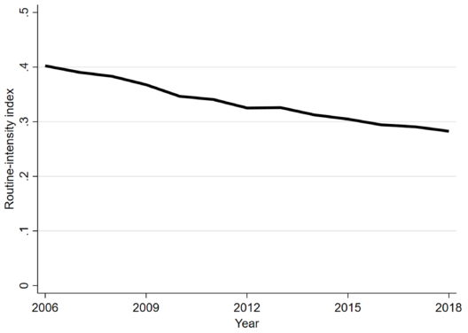

NOTE: figure/graphic rendered as an image from the PDF; its content is not machine-readable text. Caption (if any) follows as the next block.

**Figure 1.** Evolution of routine task intensity in Brazil *Source*: Own elaboration. The routine task intensity (RTI) index is based on Goos *et al.* (2014). The following occupations are dropped: legislators and senior officials (ISCO 11); teaching professionals and teaching associate professionals (ISCO 23 and 33); skilled agricultural and fishery workers (ISCO 61); and agricultural, fishery, and related laborers (ISCO 92).

routine-biased technological change (RBTC) hypothesis argues that computers and robots have diminished the demand for routine, repetitive tasks in production, which usually concentrates among middle-earning workers (Autor *et al.*, 2003; Goos *et al.*, 2009; Acemoglu and Autor, 2011). The phenomenon of job polarization and its association with technology adoption have been largely tested and confirmed in the context of advanced economies (see, for instance, Michaels *et al.*, 2014; de Vries *et al.*, 2020; Goos *et al.*, 2009; Autor *et al.*, 2003; Acemoglu and Autor, 2011; Spitz-Oener, 2006; Dustmann *et al.*, 2009; Fonseca *et al.*, 2018). The picture is less clear in developing economies, however, where indications of job polarization are considerably weaker.<sup>1</sup>

Despite this lack of apparent “hollowing out” in the middle of the distribution consistent with job polarization, the empirical literature suggests a decline in routine task intensity (RTI) across countries and that technological progress has diminished the demand for routine-intensive occupations in developing countries – which is a crucial precondition for polarization. For instance, Gasparini *et al.* (2021) show a decline in job growth in routine-intensive occupations in Latin America’s largest economies, and Reijnders and de Vries (2018) document an increasing share of non-routine occupations in developing countries’ labor forces. In Brazil, Firpo *et al.* (2021) show that despite the lack of job polarization, the RTI of occupations declined considerably. Figure 1 highlights this result, displaying the decline of routine tasks in Brazil from 2006 to 2018.

Regardless of polarization, a critical question for developing countries is the implications of this decline in routine-intensive occupations in labor outcomes, where the extent of job insecurity and informality is larger, and wages are critical for the income distribution. It remains unclear whether workers employed in routine-intensive occupations are already facing the adverse effects of this process, which groups of workers are experiencing the adverse effects more strongly, and

1 Maloney and Molina (2019) and Das and Hilgenstock (2018) find little evidence of labor market polarization or increased inequality in developing countries, either in absolute employment levels or in workforce share. Gasparini *et al.* (2021) find similar results for Latin America’s six largest economies, showing no evidence for polarization in the labor market. Martins-Neto *et al.* (2021) offer a literature review of job polarization in developing economies.

Page 3

Routine-biased technological change and employee outcomes after mass layoffs **557**

how large this effect is. So far, most studies in developing economies have focused primarily on aggregate outcomes such as changes in occupational employment and the extent of job polarization, thus failing to observe workers’ transitions across occupations and the effects on individuals’ wages and unemployment duration. This paper helps fill this gap.

One challenge when measuring the impact of exogenous changes in the demand for routine tasks on labor outcomes is the fact that it is difficult to disentangle the effects of “routinization” from endogenous decisions and responses from workers. Therefore, we employ an event-study approach (Jacobson *et al.*, 1993; Couch and Placzek, 2010; Raposo *et al.*, 2021; Blien *et al.*, 2021), treating mass layoffs as an exogenous shock. Specifically, to better identify the role of “routinization” on employment outcomes, we use this exogenous sizable negative shock—mass layoffs—and explore how re-employment probabilities and wage dynamics vary by the level of occupations’ intensity RTI.

We contribute to the labor economics literature on outcomes across displaced workers. Following the seminal work of Jacobson *et al.* (1993), studies have found that workers face a significant decline in salaries after displacements, with sustained effects ranging from 3% to 25% depending on the region and methodology.<sup>2</sup> Using Brazil’s matched employer–employee dataset (RAIS) in the mid-1990s, Menezes-Filho (2004) finds that high-tenure workers suffer a long-term loss in monthly wages of about 20% per year. Saltiel (2018) found similar results for Brazilian labor market outcomes over 2002–2012: affected workers suffer annual earnings losses exceeding 15–20%, and the effect persists through the medium term. We contribute to this literature by examining a number of heterogeneities across workers’ groups while also exploring a larger and more recent sample. For instance, Menezes-Filho (2004) focuses on male workers in the state of São Paulo and Saltiel (2018) includes only displaced workers who do not face longer periods of unemployment, thus underestimating the impacts of displacement. In addition, following Lachowska *et al.* (2020), Fallick *et al.* (2021), and Bertheau *et al.* (2022), we estimate the loss of employer-specific wage premia.

We also contribute to the recent literature on labor economics that investigates the effects of technological change and occupational differences across displaced workers. Bessen *et al.* (2019) explore the direct impact of technology adoption at the firm level on workers’ probability of separation from their current jobs and their future labor prospects.<sup>3</sup> They find that automation at the firms increases workers’ separation risk and that displaced workers are more likely to work fewer days in subsequent years. However, unlike our analysis, they do not explore differences between workers previously employed in different occupations. Goos *et al.* (2021) examined survey data of workers previously employed in a large Belgian automotive plant. After the plant closed, and in line with RBTC, workers in routine-intensive occupations were less likely to find a job 1.5 years later. Additionally, for those workers who found a job, the non-routine content of job tasks was higher, wages were lower, and permanent jobs were less frequent. In line with our results, they find a more significant impact on wages and employment for displaced workers previously employed in routine-intensive occupations (compared to their non-routine-intensive counterparts). However, they focus on a case study of one firm, which raises questions about possible selection bias, endogeneity, and generalizability of the results. Closest to our paper is Blien *et al.* (2021)’s analysis of German displaced workers (1980–2010), which tests whether workers in routine-intensive occupations are disproportionately affected by job separation. They find evidence that workers in routine occupations undergo more considerable and more persistent wage losses and that the difference compared to non-routine workers increased over time.

An important contribution of this study is to examine the impact of RBTC in the context of a middle-income country (i.e. Brazil). Brazil presents an interesting case for comparison for various reasons besides the previously mentioned weaker evidence of job polarization. First, labor market institutions have exacerbated labor market frictions and mismatches. For instance, hiring costs and firms’ entry costs in the form of taxes and bureaucracy burden are large in Brazil

2 See e.g. Couch and Placzek (2010); Raposo *et al.* (2021); Hijzen *et al.* (2010); Huttunen *et al.* (2006); Eliason and Storrie (2006); Ichino *et al.* (2017); Menezes-Filho (2004); Kaplan *et al.* (2005).

3 See also Domini *et al.* (2021); Domini *et al.* (2022).

Page 4

**558** A. Martins-Neto *et al.*

(Ulyssea, 2010), such that workers are more likely to bear the brunt of adjustment costs associated with shocks (Hollweg *et al.*, 2014). Second, minimum wage policies have helped decrease wage inequality significantly in the last decade, and the wage gap between low- and high-skilled workers narrowed significantly (Alvarez *et al.*, 2018; Firpo *et al.*, 2021). Third, productivity growth has remained stagnant, suggesting weak technological change. Fourth, in many developed economies, participation in global value chains (GVCs) spurred “routinization.” However, Brazil remained relatively isolated from global offshoring, with low participation in GVCs and services trade due to restrictive trade policies and lack of skills. This combination of labor institutions and the lack of internationalization of Brazilian companies makes the country an interesting case study to explore “routinization.”

An additional contribution is the heterogeneity analysis, including differences by gender, tenure, and firms’ size. These dimensions seem to play a critical role in explaining the adverse effects of displacement. Also, we explore some possible mechanisms explaining the larger decline in wages, especially the roles of demand, job switchers, and firms’ heterogeneity.

We observe a significant and long-lasting negative impact of job displacement on workers’ wages and employment. Based on Jacobson *et al.* (1993)’s methodology, there is a large and statistically significant wage loss associated with job displacement. Workers in the treated arm see their relative monthly earnings decline over 20% in the year following the layoff and up to 5% five years after the event. The shock also affects workers’ relative employment, as displaced individuals work over 15% less in *t* + 1 and 3% less five years after the layoff. We also find that the loss of employer-specific wage premiums explains 13% of the decline in wages for the treated group. We then test for differences between routine and non-routine workers. First, we find strong evidence that workers in routine-intensive occupations are more impacted than those in nonroutine occupations. An increase of one point in the routine-intensity index results in a further decline of 2% in workers’ relative wages and an increase of 1% in the chance of unemployment. Second, heterogeneity analysis suggests a more significant decline in wages for male, less educated, and long-tenured individuals in routine-intensive occupations. In addition, our findings suggest that the negative impact is larger in sectors with a larger decline in the demand for routine tasks. Third, workers in routine-intensive occupations are more likely to change occupations after the shock. However, those unable to switch fields experience a more significant decline in wages. Lastly, we find that the loss of employer-specific wage premia does not explain routine-intensive workers’ more substantial reduction in wages.

**2. Data and sample construction** 2.1 Data To estimate the impact of displacement on wages in Brazil, we use the RAIS database (Relação Anual de Informações Sociais) from 2006 to 2018. This is an administrative database from the Brazilian Ministry of Economy, considering a high-quality census of the Brazilian formal labor market. The census includes all establishments nationwide with at least one registered worker— even though we carry our analysis at the establishment level, we refer to firms and establishments interchangeably. The data include over 40 million employees per year, matched with firm information, including location and industry, and workers’ gender, age, education, employment status, wages, type of contract, tenure, and hiring date. RAIS reports compensation as the monthly average wage received by each worker (including regular salary payments, holiday bonuses, performance-based and commission bonuses, tips, and profit-sharing agreements).

We restrict our analysis to employees in private establishments and focus on workers displaced in 2009–2013 due to establishments’ closure or mass layoffs (see definition later). We observe workers’ outputs 3 years before displacement and 5 years following the event. This period

Page 5

Routine-biased technological change and employee outcomes after mass layoffs **559**

includes both a moment of fast national economic growth (2009–2012) and a period of economic stagnation with recessions in 2015 and 2016 when GDP dropped by 3.5% and 3.2%, respectively. Thus, for workers displaced in 2009, the booming labor market should have facilitated their reinsertion. In contrast, for workers displaced in 2013, the entire period following the shock is a period of wage stagnation and increased unemployment.

The database includes information on each worker’s occupation, coded according to the Brazilian Code of Occupations (CBO). To measure the task content of occupations, we map information from the O*NET database to the CBO. Despite the increased availability of surveys collecting information on tasks performed by individual workers, including the Program for International Assessment of Adult Competencies (PIAAC) by the Organisation for Economic Co-operation and Development (OECD) and the Skills Toward Employment and Productivity (STEP) by the World Bank, information is not available for the case of Brazil. Therefore, to explore RTI in developing economies, many authors have opted to use the O*NET database, assuming that the task content across occupations is similar across countries (e.g. World Bank, 2016; Maloney and Molina, 2019; Aedo *et al.*, 2013; Arias *et al.*, 2014). Nevertheless, recent research has indicated that the task content may differ across countries and is notably correlated with income per capita (Lewandowski *et al.*, 2019). For a given occupation, workers in high-income countries perform fewer routine tasks than those in poorer economies. Although we agree that country-specific measures of RTI would improve the estimates, using O* NET is a reasonable approximation for Brazil for two main reasons. First, the central assumption in our paper is that the ranking of occupations in terms of RTI may not vary significantly across countries. In other words, if technology adoption reduces the routine content of occupations, we assume that it equally affects all occupations, resulting in a similar ranking across countries- a manager will perform fewer routine tasks than an office clerk, irrespective of the country. This assumption is empirically confirmed by Dicarlo *et al.* (2016), who indicates that rankings of occupations along the skill dimensions are quite stable across countries. Moreover, Brazil is an upper-middle-income country. As a result, differences in RTI for a given occupation would not be as significant.

Therefore, we follow Goos *et al.* (2014), who mapped the RTI index to ISCO-88 occupations. The RTI measure is based on Autor *et al.* (2003) and combines five task measures from the US Dictionary of Occupational Titles (DOT) to produce three aggregate measures: manual, routine, and abstract task measures.<sup>4</sup> The RTI index takes the difference between the log of routine tasks and the sum of the log of abstract and the log of manual tasks. We map these occupations to the Brazilian Code of Occupations. Table 1 describes the occupations ranked by the level of routine tasks; RTI is highest at 2.24 for office clerks (41) and lowest at -1.52 for managers of small enterprises (13).

2.2 Sample construction and matching Our identification strategy rests in examining the impacts of a sudden exogenous shock on workers’ career prospects. Specifically, we look at individuals displaced due to establishments’ closures or mass layoffs. Yet, the RAIS database does not carry information on the year an establishment closes. Instead, as is commonly done in the literature, we use the establishment’s unique identifier and define exits when the employer identifier ceases to exist (see, for instance, Schwerdt *et al.*, 2010). For example, we assign an establishment in 2010 as closed if it appears in our database in the years preceding 2010 and disappears afterward. Furthermore, we define mass layoffs when 30% or more workers are laid off between *t* −1 and *t*. We impose an additional restriction to avoid capturing seasonal changes in employment and exclude cases in which employment fluctuated by 20% in the 2 years before the mass layoff or the firm size went above 150% compared to the year of the layoff. To put it simply, we exclude cases in which the trend was already perceived

4 Specifically, manual tasks relate to the occupation’s demand for “eye–hand–foot coordination” (EYEHAND), and abstract tasks refer to the simple average of occupations’ managerial and interactive tasks (DCP) and mathematical and formal reasoning requirements (GED-MATH). In contrast, the routine task measure is a simple average of the following variables: “set limits, tolerances and standards” (STS), which measures an occupation’s demand for routine cognitive tasks, and “finger dexterity” (FINGDEX), which measures an occupation’s use of routine motor tasks.

Page 6

**560** A. Martins-Neto *et al.*

**Table 1.** Routine task intensity by occupation

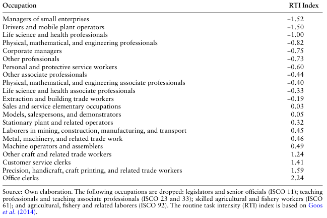

NOTE: complex table shown as an image of the PDF; the text below is a rough machine extraction and may be mis-aligned.

**extracted text (unreliable layout)**

in the years before or when employment recovers in the years following. In addition, some of these events might not be actual closures. Establishments can change their identifier in time or spin-off into different companies. We impose an additional restriction to capture these cases and exclude cases in which more than 50% of the employees continue under a new employer identifier.<sup>5</sup>

As it is commonly done in the mass layoff literature, we restrict our sample to full-time primeage workers, focusing on individuals older than 25 or younger than 50 years in the first year of analysis (for instance, for workers displaced in 2010, the first year of study is 2007). The reason to restrict workers’ age is that younger workers can be working as apprentices or interns, while older workers can opt to leave the market and retire. We also restrict establishments’ size, focusing on establishments with at least 30 employees in the first year before the event. We also limited our sample to one observation per worker-year by choosing the highest-paying in any given year for those workers with multiple full-time employment. We also excluded observations where the data were miscoded or missing. Furthermore, we impose that displaced individuals work in the same company for at least 3 years before the layoff. By setting this restriction, we focus on workers in stable positions, who would have likely continued had the closure not occurred.

To estimate the effects of displacement, we include a control group with workers who continue to work at firms that had no mass layoff during the period of analysis. For this control group, we also impose at least 3 years of tenure before the “potential displacement.” In our analysis, displacement affects workers at different times (i.e. there is variation in treatment timing, Roth *et al.*, 2022), and therefore, to ensure the validity of the difference-in-difference (DiD) setup, we guarantee that the control group includes only workers who will never be part of a mass layoff in subsequent years (de Chaisemartin and D’Haultfœ uille, 2020), hence avoiding the problem of “forbidden” comparisons (Roth *et al.*, 2022). However, other than that, we do not include any additional restriction in the years following the “potential displacement.” In other words,

5 One downside in using RAIS database is that it only covers formal workers. In this scenario, if a worker becomes unemployed or moves to the informal sector, which comprises about 40% of the Brazilian labor market, we will not be able to track her. Therefore, transitions from the formal to the informal are not captured in our analysis, being thus treated as movements to unemployment.

Page 7

Routine-biased technological change and employee outcomes after mass layoffs **561**

we aim to compare long-tenured workers with a control group of individuals who are as similar as possible in all domains, except for the displacement.

To identify a set of control workers, we implement a two-stage matching procedure in *t* −2. First, we perform exact matching on workers’ occupations (2-digits), gender, and on Brazil’s 27 states. In the second step, we implement the coarsened exact matching (CEM) algorithm (Iacus *et al.*, 2012). Then, we apply the CEM algorithm on a series of covariates at both worker level (wage, wage growth, age, tenure, and education) and establishment level (number of workers, average salary, and sector (2-digits)).<sup>6</sup> By including workers’ wage growth, we ensure that workers display similar trends in salaries before the shock, a key identification restriction of the DiD estimator.

This matching procedure yields a sample of about 135 thousand treated workers and 135 thousand workers in the control group. Table 2 shows the descriptive statistics of various workers’ and establishments’ characteristics for workers in the treatment and control arms 2 years before the layoff. The last column shows the difference between the means. Workers in the treatment group earn slightly more than the treated individuals although the difference is not statistically significant. Displaced workers have similar age and tenure as the control group and work in larger firms. In contrast, firms’ average wage is not statistically different between displaced and control workers. As expected, most individuals in our sample are placed in the southeast of Brazil. This is the most populous region in the country and includes the state of São Paulo, the wealthiest state in Brazil. In addition, about one-third is employed in the manufacturing sector, and about one-third of workers in the sample are female. Less than 10% of our sample has a college degree. In contrast, 49% has only a high-school diploma (Figure A1 shows the histogram of the routine-intensity index for the matched sample).

#### **3. Empirical strategy**

We are interested in exploring how workers in different occupational groups respond to a sudden shock in their careers. In doing so, we follow extensive literature and employ an event-study approach (Jacobson *et al.*, 1993; Couch and Placzek, 2010; Raposo *et al.*, 2021; Blien *et al.*, 2021). Mass layoffs are taken as external shocks to estimate the effect of an involuntary job loss on earnings and employment prospects. In essence, we aim to compare the wage and employment changes of treated individuals over the medium-run with the wage changes that would have occurred if they had not lost their jobs. Given that we are not able to observe the latter, we build a control group. In doing so, a robust methodology is the use of matching techniques in combination with DiD methods (see Heckman *et al.*, 1997; Cunningham, 2021; Blien *et al.*, 2021). Following the matching procedure described in the previous section, we follow Jacobson *et al.* (1993) and estimate:

**equation / math rendering (image)**

NOTE: contains mathematical notation; text above is the PDF text layer and symbols may be mis-extracted. Image shows the original.

**equation / math rendering (image)**

NOTE: contains mathematical notation; text above is the PDF text layer and symbols may be mis-extracted. Image shows the original.

where *yit* is the outcome of interest (relative monthly salary or employment). Relative wages are measured compared to worker’s compensation in *t* −2, while employment is a dummy equal to 1 if the worker has any positive labor earnings in a given year. Wages are taken as zero whenever the individuals are unemployed. *Ti* is a treatment indicator that is equal to 1 if the worker faced a layoff and 0 otherwise, and 𝜈*t* represents time-to-event dummies, from 3 years before the event to 5 years after it (*t* −2 is the baseline). The coefficients 𝛽*k* are our outcome of interest and measure the differences in relative earnings or relative employment for displaced and non-displaced workers from 3 years before the shock to 5 years after. 𝜆*i* and 𝜃*t* represent individual and time fixed effects and capture permanent unobserved individual characteristics and general patterns in the economy, respectively. In contrast, 𝜎*j* and 𝛿*s* represent common region and sector effects.

6 We have not imposed any bins in our matching strategy and have used the binning algorithm autocuts proposed in the CEM command in Stata.

Page 8

**562** A. Martins-Neto *et al.*

**Table 2.** Comparison of treated and control groups after matching

[output not shown]

NOTE: table converted from PDF layout to HTML text; cell boundaries are reconstructed. See PDF if exact alignment matters.

Table shows averages for baseline. The last column is the coefficient of a simple regression of treatment status on the variable, with robust standard errors. The groups are perfectly matched for gender, occupation, and state. Stars indicate whether this difference is significant. **P* < 0.10, ***P* < 0.05, ****P* < 0.01.

To estimate the difference between routine and non-routine occupations, we follow Blien *et al.* (2021) and modify Equation 1 such that:

**equation / math rendering (image)**

NOTE: contains mathematical notation; text above is the PDF text layer and symbols may be mis-extracted. Image shows the original.

**equation / math rendering (image)**

NOTE: contains mathematical notation; text above is the PDF text layer and symbols may be mis-extracted. Image shows the original.

where *RTIi* is the RTI index described in Table 1. In addition to worker fixed effects, timeto-event dummies, and regular year, region, and sector dummies, Equation 2 also includes interactions between time-to-event dummies and the RTI index (𝛼*k*𝜈*<sup>k</sup>*

#### **4. The adverse effects of job displacement**

We start by first exploring the impact of job displacement on wages and employment in Brazil. Figure 2 plots the coefficients from Equation 1 and shows as expected that displaced individuals

Page 9

Routine-biased technological change and employee outcomes after mass layoffs **563**

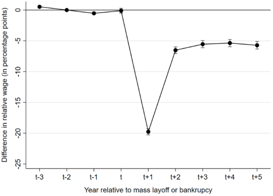

NOTE: figure/graphic rendered as an image from the PDF; its content is not machine-readable text. Caption (if any) follows as the next block.

**Figure 2.** Effect of displacement on relative wages The figure shows the estimates of time-to-event dummies interacted with a displacement indicator from a regression including individual, region, sector, time-to-event dummies, and year fixed effects. The dependent variable is relative wages. Relative wages are measured dividing worker’s monthly average wage by the worker’s average wage in year *t* −2. Year *t* −2 is the base year. Vertical bars show estimated 95% confidence interval based on standard errors clustered at the individual level.

Figure 3 presents the effect on the other outcome of interest, workers’ employment. In years preceding the shock, given that workers were employed full time, the coefficients are equal to zero. However, following the displacement, treated workers are 18% less likely to be in formal jobs than the control group. In the following years, the impact on employment declines to 5%, with the impact lasting over the medium-run. For instance, in year *t*+5, displaced individuals are 3.4% less likely to be in formal employment than the control group (Table A1 in the Appendix presents the coefficients for each year).

We further explore the heterogeneity of our results and group workers into different categories to examine some of the drivers of the adverse effects of displacement. Table 3 shows the baseline estimates of the averages of the estimates over the 6 years from the shock (from *t* to *t* + 5) of timeto-event dummies interacted with a displacement indicator from a regression including individual, region, sector, time-to-event dummies, and year fixed effects.

Page 10

**564** A. Martins-Neto *et al.*

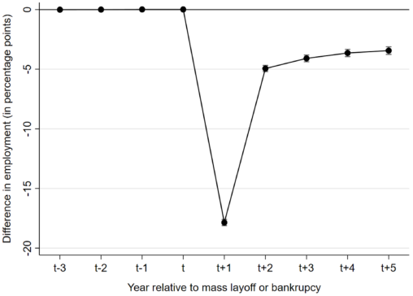

NOTE: figure/graphic rendered as an image from the PDF; its content is not machine-readable text. Caption (if any) follows as the next block.

**Figure 3.** Effect of displacement on employment The figure shows the estimates of time-to-event dummies interacted with a displacement indicator from a regression including individual, region, sector, time-to-event dummies, and year fixed effects. The dependent variable is employment. Employment is a dummy equal to 1 if the worker has any positive labor earnings in a given year. Year *t* −2 is the base year. Vertical bars show estimated 95% confidence interval based on standard errors clustered at the individual level.

**Table 3.** Effect of displacement on relative wages and employment by group

[output not shown]

NOTE: table converted from PDF layout to HTML text; cell boundaries are reconstructed. See PDF if exact alignment matters.

The table shows averages of the estimates over the 6 years from the shock (from *t* to *t* + 5) of time-to-event dummies interacted with a displacement indicator from a regression including individual, region, sector, time-to-event dummies, and year fixed effects. In other words, the table shows the “average over years” obtained from a single dummy variable for the entire period *t*:*t*+5. The dependent variables are relative wages and employment. Relative wages are measured dividing worker’s monthly average wage by the worker’s average wage in year *t* −2. Employment is a dummy equal to 1 if the worker has any positive labor earnings in a given year. Year *t* −2 is the base year. Standard errors clustered at the individual level are reported in parentheses. ***, **, and *, respectively, indicate 0.01, 0.05, and 0.1 levels of significance.

Page 11

Routine-biased technological change and employee outcomes after mass layoffs **565**

Several interesting facts emerge. First, in terms of employment, and consistent with the literature (Deelen *et al.*, 2018), the adverse effects are more significant for older workers. 42 years or older workers face a decline in employment about 1.5 percentage points larger than younger individuals. In contrast, older workers are less affected in terms of relative wages. In addition, similar to Saltiel (2018), the impact is more significant for long-tenured workers, reflecting the importance of breaking employer–employee matching and the destruction of firm-specific human capital for explaining sustained wage losses. Workers with over 85 months of experience in the same firm see their wages declining on average 8.7% relative to 2 years before the displacement, while short-tenured individuals see a decline of 6%. Long-tenured workers are also more impacted by a decrease in relative employment (7.4%) than short-tenured workers (5%). We also find that male workers are less impacted than female individuals in terms of relative wages and employment. The results are different from those observed in Carneiro and Portugal (2006), who use Portuguese matched employer–employee database and find that the effects of displacement are larger for men (12%) than women (9%). In addition, we find that high-educated workers are more significantly affected in terms of wages and employment. Furthermore, workers in smaller companies see a more substantial decline in wages and employment than those in larger companies.

**5. Routine task intensity and the cost of displacement** 5.1 The role of tasks Mass layoffs are a natural experiment to explore the role of RTI in the impact on workers, given that they represent an exogenous and often unexpected shock to workers. If wages solely reflect workers’ observable characteristics, pre- and post-displacement wages should show minor variation. However, some factors external to the worker can affect the labor outcomes of the displaced. Critical among these factors are those that affect the RTI of those tasks. A first element that suggests that the type of tasks carried out by the worker matters is technology. Technological progress does not equally affect all occupations. For example, a well-known fact is that automation diminishes the demand for routine tasks (Autor and Dorn, 2013), so that workers in routine-intensive occupations suddenly find themselves in a less favorable market, making it a challenge to recover from losing their jobs. Arnoud (2018) shows that even under low technology adoption, the threat of automation can lower wage growth of occupations more susceptible to automation. Second, structural transformation and the decreasing share of manufacturing in the economy can also reduce the demand for routine intensive occupations and worsen the outcomes of displaced workers in those sectors (Bárány and Siegel, 2018).

Table A2 shows the results of a similar exercise than in Table 3 and reinforces the fact that workers in high-routine occupations are more impacted in terms of wages. In addition, Figure 5 shows that workers in the fourth quartile are 2% more likely to face unemployment in the years following the shock.

These initial results, however, do not account for some critical differences between occupational groups, especially the fact that trends in wages might differ between occupational groups. A more formal estimate is presented in Figure 6, which offers the estimates from Equation 2 and presents the coefficient of the triple interaction term (𝜌*k*) taking relative wages as the dependent variable. Table A5 in the Appendix shows the coefficients for both wages and employment. The interpretation of these estimates is by how many percentage points the earnings loss in a specific year is magnified due to an increase in 1 point in the RTI index, which in turn varies from -1.52 to 2.24.

Page 12

**566** A. Martins-Neto *et al.*

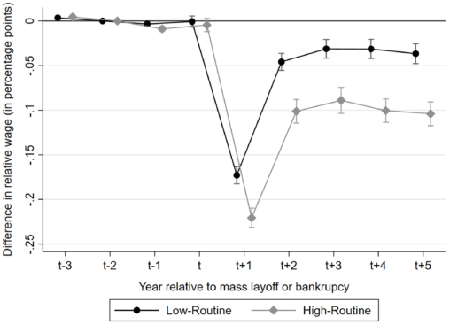

NOTE: figure/graphic rendered as an image from the PDF; its content is not machine-readable text. Caption (if any) follows as the next block.

**Figure 4.** Effect of displacement on relative wages by occupational group The figure shows the estimates of time-to-event dummies interacted with a displacement indicator from a regression including individual, region, sector, time-to-event dummies, and year fixed effects. The dependent variables are relative wages. Relative wages are measured dividing worker’s monthly average wage by the worker’s average wage in year *t* −2. Year *t* −2 is the base year. Low routine are workers in the first quartile of the routine-intensity index, while high routine indicates workers in the fourth quartile. Vertical bars show estimated 95% confidence interval based on standard errors clustered at the individual level.

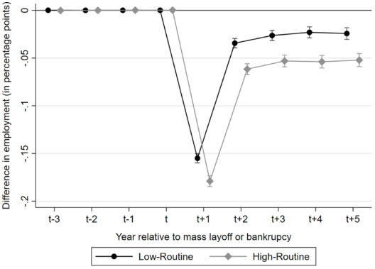

NOTE: figure/graphic rendered as an image from the PDF; its content is not machine-readable text. Caption (if any) follows as the next block.

**Figure 5.** Effect of displacement on employment by occupational group The figure shows the estimates of time-to-event dummies interacted with a displacement indicator from a regression including individual, region, sector, time-to-event dummies, and year fixed effects. The dependent variables is employment. Employment is a dummy equal to 1 if the worker has any positive labor earnings in a given year. Year *t* −2 is the base year. Low routine are workers in the first quartile of the routine-intensity index, while high routine indicates workers in the fourth quartile. Vertical bars show estimated 95% confidence interval based on standard errors clustered at the individual level.

Page 13

Routine-biased technological change and employee outcomes after mass layoffs **567**

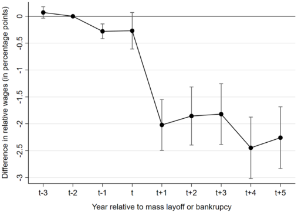

NOTE: figure/graphic rendered as an image from the PDF; its content is not machine-readable text. Caption (if any) follows as the next block.

**Figure 6.** Routine task intensity and the effect of displacement on relative wages The figure shows the estimates of the triple interactions between time-to-event dummies interacted with a displacement indicator and a RTI measure from a regression including individual, region, sector, time-to-event dummies, time-to-event dummies interacted with the RTI measure, and year fixed effects. The dependent variables are relative wages. Relative wages are measured dividing worker’s monthly average wage by the worker’s average wage in year *t* −2. Year *t* −2 is therefore the base year. Vertical bars show estimated 95% confidence intervals based on standard errors clustered at the individual level.

The results suggest that an increase of 1 point in the RTI results in a further decline of about 2% in relative wages across the years and up to 5 years following the shock. For instance, a worker previously employed in metal and machinery (RTI equals 0.46) would face a decline of 2% lower than a worker once hired as precision, handicraft, and craft printing (RTI equals 1.59). In addition, Figure 7 shows that workers in routine-intensive occupations are also more likely to face more extended periods of unemployment—a 1 point increase in the RTI increases the chance of unemployment by 1%. Our findings are similar to those in Blien *et al.* (2021) and Goos *et al.* (2021), who also find a negative impact of being previously employed in routineintensive occupations. In addition, the results are somewhat consistent with Firpo *et al.* (2021), who find some evidence of earnings polarization in Brazil.<sup>7</sup>

Keeping our focus on job displacement and RTI, we investigate the robustness of our findings according to heterogeneity in individuals’ characteristics.<sup>8</sup> Table 4 examines the heterogeneity of these findings, as in Table 3, while estimating Equation 2. Some interesting findings emerge in the analysis of relative wages. First, as in the previous results, the effect of routine-intensity is larger for long-tenured individuals. Second, we observe that the impact is more significant for male and less-educated individuals. Lastly, the impact is larger for workers previously employed in larger establishments. As for employment, we observe similar results. Older and long-tenure individuals face more extended periods of unemployment. In addition, female and college graduate workers do not show statistically significant results. In the following section, we try to account for these

7 Regarding the more significant adverse effect of displacement for workers in high-routine occupations, Table A3 suggests that these workers are less likely to be part of a mass layoff (compared to a firm closure). Workers experiencing a mass layoff are significantly less routine intensive on average than workers experiencing a firm closure (RTIs of 0.17 vs 0.31, respectively, *P*-value < 10%).

8 We cannot rule out that our estimates for RTI and displacement outcomes may not correspond to causal estimates of RTI on displacement outcomes because of potential correlations between RTI and workers’ characteristics (such as gender, education, or other variables that remain unobserved). While a detailed analysis of workers’ characteristics is beyond the scope of the current paper, further work on different samples would be welcomed.

Page 14

**568** A. Martins-Neto *et al.*

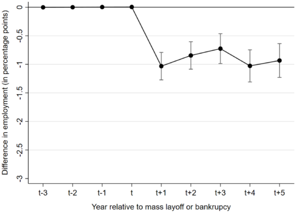

NOTE: figure/graphic rendered as an image from the PDF; its content is not machine-readable text. Caption (if any) follows as the next block.

**Figure 7.** Routine task intensity and the effect of displacement on employment The figure shows the estimates of the triple interactions between time-to-event dummies interacted with a displacement indicator and a RTI measure from a regression including individual, region, sector, time-to-event dummies, time-to-event dummies interacted with the RTI measure, and year fixed effects. The dependent variables is employment. Employment is a dummy equal to one is the worker has any positive labor earnings in a given year. Year *t* −2 is therefore the base year. Vertical bars show estimated 95% confidence intervals based on standard errors clustered at the individual level.

significant impacts, considering differences across sectors, the role of job switchers, and firm heterogeneity.

Our main finding suggests that workers in routine-intensive occupations face a more considerable decline in wages and employment following a mass layoff. In other words, there is evidence of non-routinization affecting workers’ outcomes in Brazil, given that the falling demand for routine workers has impacted their ability to find similar, good-paying jobs. As a result, a critical question is to understand what are the main mechanisms that could explain these effects on workers.

5.2 The role of decreasing demand In exploring the possible mechanisms, we first look at differences in the demand for routine occupations across sectors and test whether workers initially employed in industries with falling demand for routine tasks are more considerably affected. Second, we test for the importance of job switchers in explaining our results. For example, following a displacement and given the lower demand for these occupations, workers may move to occupationally distant jobs, which is usually associated with lower re-employment wages (Lysho, 2020; Huckfeldt, 2018). Therefore, we examine first whether workers in routine occupations are more likely to switch fields, and then we test for different impacts among switchers and non-switchers. Lastly, differences in firm characteristics can help shed some light on our results. In particular, there are significant differences in firms’ wage premiums in Brazil (Alvarez *et al.*, 2018). In this context, we examine whether workers in routine occupations are more likely to move to low-paying firms upon reemployment. Given the decline in the demand for such occupations, displaced individuals could face more difficulties finding a better-paying firm, thus ending with a lower wage.

Figure 1 shows a constant decline in RTI in Brazil from 2006 to 2018. Yet, the aggregate measure hides significant heterogeneity across sectors. The decrease in the demand for routine occupations combines within-industry and between-industry changes. On the one hand, as firms adopt more sophisticated and automated technologies, a given industry will use less routine

Page 15

Routine-biased technological change and employee outcomes after mass layoffs **569**

**Table 4.** Effect of routine task intensity on relative wages and employment by group

[output not shown]

NOTE: table converted from PDF layout to HTML text; cell boundaries are reconstructed. See PDF if exact alignment matters.

The table shows averages of the estimates over the 6 years from the shock (from *t* to *t* + 5) of the triple interactions between time-to-event dummies interacted with a displacement indicator and a RTI measure from a regression including individual, region, sector, time-to-event dummies, time-to-event dummies interacted with the RTI measure, and year fixed effects. In other words, the table shows the “average over years” obtained from a single dummy variable for the entire period *t*:*t*+5. The dependent variables are relative wages and employment. Relative wages are measured by dividing workers’ monthly average wage by the average wage in year *t* −2. Employment is a dummy equal to 1 if the worker has any positive labor earnings in a given year. Standard errors clustered at the individual level are reported in parentheses. ***, **, and *, respectively, indicate 0.01, 0.05, and 0.1 levels of significance.

employment to produce similar output levels. On the other hand, RTI differs across sectors, such that sectoral employment shifts also explain aggregate occupational share changes (Goos *et al.*, 2014).

As a first exercise, we test for the association between initial RTI across sectors and the change in employment share from 2006 to 2018. Figure 8 shows a negative correlation, albeit weak, between RTI and employment change across industries in Brazil, hence suggesting that most of the changes in the index might have occurred within sectors. To have a better grasp of these dynamics, we decompose the difference from 2006 to 2018 in the RTI index into changes within and between industry groups:

Δ*RTI* = ∑

**equation / math rendering (image)**

NOTE: contains mathematical notation; text above is the PDF text layer and symbols may be mis-extracted. Image shows the original.

*i*

*i*

*i*

where *i* indexes industries. *RTIi* accounts for the routine-intensity (measured as the occupational weighted index) of industry *i* and Δ*RTIi* accounts for the change in RTI of unit *i*. *Si* is the share of industry *i* in total employment, and Δ*Si* is the change in the share in total employment of industry *i* over the period. The first term in the RHS is the contribution of RTI growth in each industry (*within industry*), assuming that employment shares remain unchanged. The second term in the RHS is related to changes in employment shares (*between industry*), while the RTI index in each sector is kept constant. Finally, the third term is a *dynamic* term, giving the contribution to the total RTI index due to a rise in the employment share in sectors whose RTI has increased in the period.

Page 16

**570** A. Martins-Neto *et al.*

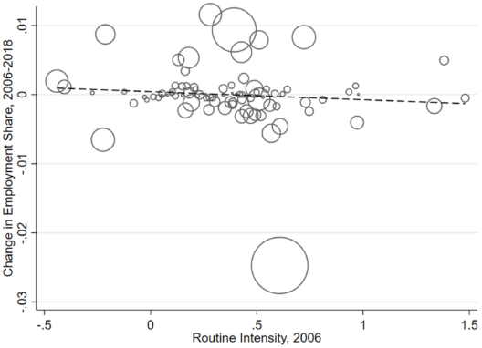

NOTE: figure/graphic rendered as an image from the PDF; its content is not machine-readable text. Caption (if any) follows as the next block.

**Figure 8.** Routine task intensity and change in industries’ employment share Circles represent 87 sectors, weighted by total employment in 2006. The x-axis is the RTI index, calculated as the weighted occupational index and ranging from -1.52 to 2.24. The y-axis is the change in the share of employment in each sector from 2006 to 2018, measured in percentage points. The coefficient in the linear regression is -0.00117, with standard error equal to 0.0012.

**Table 5.** RTI decomposition, 2006–2018

[output not shown]

NOTE: table converted from PDF layout to HTML text; cell boundaries are reconstructed. See PDF if exact alignment matters.

All proportions and means are weighted by occupational employment in 2006 or 2018. Δ is the change in the average proportion or mean from 2006 to 2018.

Table 5 presents the results of the shift-share decomposition. From 2006 to 2018, the RTI index in Brazil dropped 0.12 points (30%), explained mainly by changes within sectors. Specifically, 94% of the decline is explained by within-sector variations, while between-sector changes explain only 10%. Figure 9 presents the change in RTI across sector over the period. (Table A6 in the Appendix shows the within-sector change in RTI for the 87 sectors over the period, ranked according to the size of the decline.) Although most research relates the decline in routine tasks to automation in manufacturing, the services industry presents a more significant decrease in RTI in Brazil. In particular, the decline in RTI in services was twice as large as that for manufacturing. Hence, we document a significant decrease in routine occupations not related to reallocation of workers but to within-sector changes and that go beyond manufacturing.

Our next step lies in using these differences across sectors. First, we divide our sample into workers initially employed in manufacturing and non-manufacturing and re-estimate Equation 2. In addition, we look at within-industry changes in the RTI index and split our sample into individuals initially employed in sectors above the median or below or equal the median. Table 6

Page 17

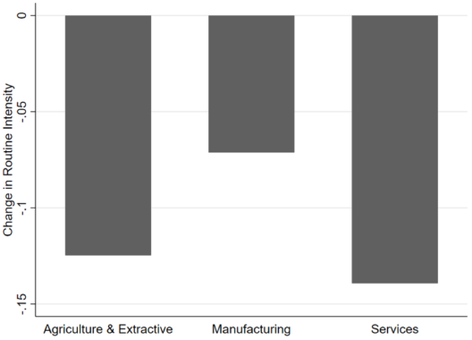

NOTE: figure/graphic rendered as an image from the PDF; its content is not machine-readable text. Caption (if any) follows as the next block.

**Figure 9.** Change in sectors’ routine task intensity The y-axis is the mean change in RTI for each sector from 2006 to 2018.

**Table 6.** Effect of displacement on wages by sector group

[output not shown]

NOTE: table converted from PDF layout to HTML text; cell boundaries are reconstructed. See PDF if exact alignment matters.

The table shows the baseline estimates of averages of the triple interactions between time-to-event dummies interacted with a displacement indicator and a RTI measure from a regression including individual, region, sector, time-to-event dummies, time-to-event dummies interacted with the RTI measure, and year fixed effects. The dependent variables are relative wages and employment. Relative wages are measured dividing workers monthly average wage by average wage in year *t* −2. Employment is a dummy equal to 1 if the worker has any positive labor earnings in a given year. Year *t* −2 is the base year. Rows (1) and (2) split the 87 sectors between non-manufacturing and manufacturing. Rows (3) and (4) split the sample into those with a decline in the RTI index below the median and above the median. The median is equal to -.055. Standard errors clustered at the individual level are reported in parenthesis. ***, **, and *, respectively, indicate 0.01, 0.05, and 0.1 levels of significance.

presents the results of both exercises, suggesting that workers previously employed in manufacturing face a larger decline in wages and more extended periods of unemployment. Furthermore, when focusing on the decline in RTI across industries, the impact is more considerable for sectors with a more significant decline in the demand for routine tasks. Therefore, demand seems to be playing a sizable role in explaining differences across occupational groups in Brazil.

5.3 Job switchers Within a more competitive labor market, with few opportunities, workers in routine occupations could be more inclined (or forced) to change fields in search for better, high-paying jobs. In this section, we estimate whether workers in routine-intensive occupations are more likely to move

**Table 7.** Routine task intensity and the probability of switching occupations

[output not shown]

NOTE: table converted from PDF layout to HTML text; cell boundaries are reconstructed. See PDF if exact alignment matters.

The table shows the baseline estimates of switching occupations and a RTI measure from a regression including individual, region, sector, and year. In columns (1) and (2), the dependent variable is a dummy variable equal to 1 if individuals switch occupations (2-digits) and 0 otherwise. In columns (3) and (4), we use a broader definition of occupation and define workers’ occupations at 1-digit level. Therefore, the dependent variable is equal to 1 if workers transition across occupations at 1-digit and 0 otherwise. Robust standard errors are reported in parenthesis. ***, **, and *, respectively, indicate 0.01, 0.05, and 0.1 levels of significance.

to different professions following a layoff and the impacts of these transitions. In doing so, we create a dummy equal to 1 if individuals switch occupations (2-digits) and 0 otherwise. In our sample, switching to a different occupation is observed for 49.743 workers (about 20% of individuals) (see Table A4 for a descriptive analysis of switchers and non-switchers). Columns (1)-(2) in Table 7 show baseline estimates that include a set of Mincerian workers’ characteristics and year, sector, and region effects. The columns differ in methodology, with column (1) using an ordinary least squares model (OLS), while column (2) employs a probit model. In addition, columns (3)-(4) show similar regressions using a different definition of job switchers, now including only individuals that change broader occupations (1-digit).

The main finding is that the routine-intensity index correlates significantly with the probability of moving to different occupations, even if not in the treatment group. The second line in Table 7 shows that treated workers (those part of a mass layoff) are also more likely to switch occupations, consistent with other findings in the literature (Nedelkoska *et al.*, 2015). We also find that treated individuals previously employed in routine occupations are more likely to transition to different professions. In addition, we observe that male and more educated workers are more

**Table 8.** Effect of displacement on wages for switchers and non-switchers

[output not shown]

NOTE: table converted from PDF layout to HTML text; cell boundaries are reconstructed. See PDF if exact alignment matters.

The table shows averages of the estimates over the 5 years from the shock (from *t* to *t* + 4) of the triple interactions between time-to-event dummies interacted with a displacement indicator and a RTI measure from a regression including individual, region, sector, time-to-event dummies, time-to-event dummies interacted with the RTI measure, and year fixed effects. The dependent variable is relative wages. Relative wages are measured dividing workers monthly average wage by average wage in year *t* −2. Year *t* −2 is the base year. Job switchers are defined as workers that change occupations between the year before the shock and the first year of re-employment. Occupations are defined at the 2-digit level. Column (1) restricts the sample to switchers, while column (2) focuses on non-switchers. Standard errors clustered at the individual level are reported in parenthesis. ***, **, and *, respectively, indicate 0.01, 0.05, and 0.1 levels of significance.

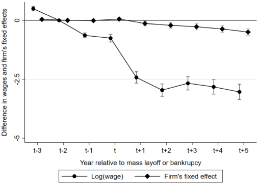

NOTE: figure/graphic rendered as an image from the PDF; its content is not machine-readable text. Caption (if any) follows as the next block.

likely to switch jobs, whereas long-tenured individuals are less likely to follow this path. Overall, the results suggest that the falling demand for routine tasks not only affects workers’ employment outcomes but also increases the likelihood to change professions.

We further test whether displacement affects job switchers differently compared to nonswitchers. In particular, we separate our sample between job switchers and those workers who remained in the same occupation (2-digits) and re-estimate Equation 2. Column (1) in Table 8

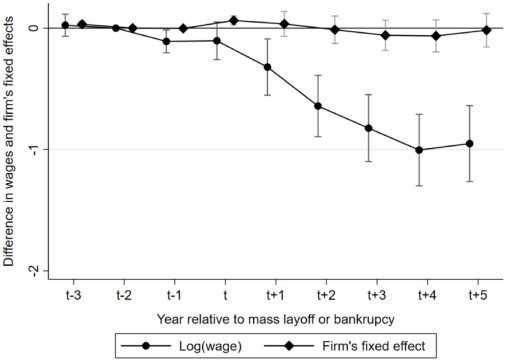

NOTE: figure/graphic rendered as an image from the PDF; its content is not machine-readable text. Caption (if any) follows as the next block.

presents the results for the group of workers who switch occupations and column (2) for the workers who have remained in the same occupational group. Interestingly, workers initially in routine-intensive occupations and moving to different occupations are significantly less affected than workers who do not switch occupations. This aligns nicely with economic intuition. Falling demand for routine tasks requires the reallocation of workers from declining occupations to other more promising—workers who comply with such inter-occupational selection dynamics should be rewarded compared to workers who “stubbornly” linger in their original declining occupation. Similarly, workers switching to other occupations presumably select from amid a broader opportunity set than workers searching only within their current occupation. Hence, switching workers would be associated with a better-matching labor market opportunity if their search space is wider.

5.4 Firms’ fixed effects A third and related mechanism to explain worse employment outcomes for routine occupations is that workers in high-routine intensive occupations have to move to low-paying and worse companies to find a job in the same field. For instance, less productive firms tend to have lower adoption of more sophisticated technologies, thus continuing to demand labor to perform routine tasks and being the main option for dismissed high-routine workers.

To test this hypothesis, we estimate whether workers in routine-intensive occupations move to low-paying companies more frequently. First, we estimate firms’ paying heterogeneity and decompose earnings using an AKM decomposition. Specifically, to calculate firms’ fixed effects, we regress the log of monthly wages on a set of individual, firm, and year fixed effects. To ease the computational burden, we estimate this specification for two different periods, 2007–2012 and 2013–2018, and limit the sample to the largest connected set within each of these samples.<sup>9</sup>

With firms’ fixed effects in hand, we estimate Equation 1 using the fixed effects as the outcome variable and compare with the impacts on workers’ logarithm of monthly wages. Figure 10 shows

9 We assume that establishments’ wage premium is set at the firm level. Therefore, we estimate establishments’ fixed effects at the company level.

the results of this exercise, indicating that the loss of employer-specific wage premium responds to about 13% of the adverse effect on wages. Our results are closer in magnitude to those in Lachowska *et al.* (2020), who finds that employer-specific premiums explain 17% of wage losses in the state of Washington but significantly smaller than those observed in Germany (Fackler *et al.*, 2021). The small effect on firm wage premium losses is likely related to a weakening passthrough from firm characteristics to wages in Brazil. For instance, Alvarez *et al.* (2018) shows the decline in firm productivity pay premium explained about 40% of the decrease in earnings inequality in Brazil between 1996 and 2012. As a result, workers are increasingly more likely to move to firms with equal paying premiums.

Following this analysis, we estimate Equation 2 to test whether the RTI is associated with movements to low-paying firms. On the one hand, Figure 11 confirms that workers previously employed in routine-intensive occupations face a more significant decline in wages, even when excluding those workers who are not employed (using the logarithm of wages excludes those workers with missing information on wages). On the other hand, Figure 11 show that the routine-intensity index is not statistically associated with a decline in firm’s fixed effects, thus suggesting that workers previously employed in routine-intensive occupations were not more likely to transition to low-paying firms.

#### **6. Conclusion**

Technological change puts pressure on certain worker groups by eroding the value of their skills, threatening their job security, and making it harder to find jobs with equivalent pay after a layoff (Braxton and Taska, 2023). While these phenomena have been widely studied in the USA and Europe, much less is known about the potential impact on employment dynamics in developing countries, where the pace of technological change is slower. This paper sheds some light on this issue for a large middle-income country, Brazil, by understanding the employment dynamics associated with routine workers and using mass layoffs as a natural experiment to better identify these effects.

In line with other evidence in developed countries, we find that job displacement has a significant impact on workers’ labor outcomes. Wages are significantly depressed in the short run and only recover partially in the medium run. Displaced workers are also more likely to face extended periods of unemployment. Workers displaced see wage declines of up to 5% even 5 years after the displacement event. In addition, consistent with most findings in the literature, we find that female, long-tenured, and older workers are more significantly affected by displacement.

But while all workers experience a significant decline in wages and employment opportunities following a mass layoff event, those in routine intensive occupations fare much worse—especially less-educated workers. While we cannot measure technological progress directly, the results show that job displacement’s adverse outcomes are worse in sectors where the demand for routine jobs has decreased over time. Moreover, while we do not find evidence of a necessary move toward “worse” firms by displaced workers, those in routine occupations are also more likely to have to switch occupations.

Several policy implications arise from these findings. First, while policies that effectively accelerate technological change have large potential returns in terms of productivity growth in developing countries, the findings of this paper identify potential negative distributional impacts on routine workers in middle-income countries as technological change accelerates. Second, workers in routine-intensive occupations appear especially vulnerable after a mass layoff because of the significant wage decrease and the difficulty of finding a new job requiring similar skills. Thus, policies aimed to re-skill the labor force are not only necessary, but they need to prioritize workers in routine-intensive occupations and sectors with a larger decrease in demand for routine-intensive occupations, supporting them in developing new skills that can help offset the harmful impacts of displacement. In addition, a more nuanced understanding of the tasks these groups perform is needed, especially of the need for soft skills that can also facilitate job transitions. As the pace of technological change and automation shows no sign of slowing down, policy interventions for training and re-skilling displaced workers can only be expected to grow in importance, also in developing countries.

Some important gaps in understanding the impact of technological change on workers’ dynamics in developing countries still remain. More granular evidence is needed linking direct events of technology upgrading with changes in the skill composition at the firm and workers’ levels. Rather than inferring technological trends based on the changes in occupation skills demand within sectors, more detailed data are needed to identify how specific technologies affect the employment outcomes of different types of workers. This requires more availability of surveys that measure technology use in establishments and that can be linked with large labor censuses and other administrative data.

#### **Acknowledgements**

We thank two anonymous referees for their useful comments and suggestions. We also benefited from comments from Jaime Arellano-Bover, Nanditha Mathew, Pierre Mohnen, Gaurav Nayyar, Duncan Roth, and Tania Treibich. We also thank seminar attendees at the World Bank’s FIE Knowledge Sharing Seminar, the UNU-MERIT seminar, and the 2022 Workshop on Technology, Employment, and Industrial Dynamics in Pisa. Antonio Martins-Neto acknowledges support from the Comprehensive Innovation for Sustainable Development (CI4SD) Research Programme of the United Nations University–Maastricht Economic and Social Research Institute on Innovation and Technology (UNU-MERIT), Maastricht, the Netherlands.

#### **References**

Abowd, J. M., F. Kramarz and D. N. Margolis (1999), ‘High wage workers and high wage firms,’ *Econometrica*,

**67**(2), 251–333. Acemoglu, D. and D. Autor (2011), ‘Skills, tasks and technologies: implications for employment and earnings.’

In: O. Ashenfelter and D. Card (Eds.), *Handbook of Labor Economics*, Vol. 4, Chapter 12, 1043–1171. Elsevier. Aedo, C., J., Hentschel, J., Luque and M., Moreno (2013), ‘From occupations to embedded skills: a cross-country

comparison,’ *Policy Research Working Paper Series*, **6560**. Aghion, P., C., Antonin and S., Bunel (2021), ‘*The Power of Creative Destruction*.’ Harvard University Press. Aghion, P. and P., Howitt (1992), ‘A model of growth through creative destruction,’ *Econometrica*, **60**(2),

323–351. Alvarez, J., F., Benguria, N., Engbom and C., Moser (2018), ‘Firms and the decline in earnings inequality

in Brazil,’ *American Economic Journal: Macroeconomics*, **10**(1), 149–89. Arias, O. S., C., Sánchez-Páramo, M. E., Dávalos, I., Santos, E. R., Tiongson, C., Gruen, N., de Andrade Falcão,

G., Saiovici and C. A., Cancho (2014), ‘*Back to Work: Growing With Jobs in Europe and Central Asia*.’ The World Bank. Arnoud, A. (2018), ‘Automation threat and wage bargaining.’ *Unpublished Manuscript, Yale University*. Autor, D. H. and D., Dorn (2013), ‘The growth of low-skill service jobs and the polarization of the us labor

market,’ *American Economic Review*, **103**(5), 1553–97. Autor, D. H., F., Levy and R. J., Murnane (2003), ‘The skill content of recent technological change: an empirical

exploration*,’ *The Quarterly Journal of Economics*, **118**(4), 1279–1333. Bárány, Z. L. and C., Siegel (2018), ‘Job polarization and structural change,’ *American Economic Journal:*

*Macroeconomics*, **10**(1), 57–89. Barbieri, L., M., Piva and M., Vivarelli (2019), ‘R&d, embodied technological change, and employment: evidence

from italian microdata,’ *Industrial and Corporate Change*, **28**(1), 203–218. Bertheau, A., E. M., Acabbi, C., Barcelo, A., Gulyas, S., Lombardi and R., Saggio (2022), ‘The unequal cost

of job loss across countries,’ *Working Paper 29727, National Bureau of Economic Research*. Bessen, J. E., M., Goos, A., Salomons and W., Van den Berge (2019), ‘Automatic reaction-what happens to

workers at firms that automate?,’ *Boston Univ. School of Law, Law and Economics Research Paper*. Blien, U., W., Dauth and D. H., Roth (2021), ‘Occupational routine intensity and the costs of job loss: evidence

from mass layoffs,’ *Labour Economics*, **68**, 101953. Braxton, J. C. and B., Taska (2023), ‘Technological change and the consequences of job loss,’ *American Economic*

*Review*, **113**(2), 279–316. Carneiro, A. and P., Portugal (2006), ‘Earnings Losses of Displaced Workers: Evidence from a Matched Employer-Employee Data Set,’ *IZA Discussion Papers 2289, Institute of Labor Economics (IZA)*.

Comin, D. and B., Hobijn (2010), ‘An exploration of technology diffusion,’ *American Economic Review*, **100**(5),

2031–59. Comin, D. and M., Mestieri (2018), ‘If technology has arrived everywhere, why has income diverged?,’ *American*

*Economic Journal: Macroeconomics*, **10**(3), 137–78. Couch, K. A. and D. W., Placzek (2010), ‘Earnings losses of displaced workers revisited,’ *American Economic*

*Review*, **100**(1), 572–89. Cunningham, S. (2021) ‘*Causal Inference: The Mixtape*,’ Yale University Press. Das, M. and B., Hilgenstock (2018), ‘The Exposure to Routinization: Labor Market Implications for Developed

and Developing Economies,’ *IMF Working Papers 2018/135, International Monetary Fund*. de Chaisemartin, C. and X., D’Haultfœuille (2020), ‘Two-way fixed effects estimators with heterogeneous

treatment effects,’ *American Economic Review*, **110**(9), 2964–96. Deelen, A., M., de Graaf-Zijl and W., van den Berge (2018), ‘Labour market effects of job displacement for prime-

age and older workers,’ *IZA Journal of Labor Economics*, **7**(1), 1–30. de Vries, G. J., E., Gentile, S., Miroudot and K. M., Wacker (2020), ‘The rise of robots and the fall of routine

jobs,’ *Labour Economics*, **66**, 101885. Dicarlo, E., S., Lo Bello, S., Monroy-Taborda, A. M., Oviedo, M. L., Sanchez Puerta and I., Santos (2016), ‘The

Skill Content of Occupations across Low and Middle Income Countries: Evidence from Harmonized Data,’ *IZA Discussion Papers 10224, Institute of Labor Economics (IZA)*. Domini, G., M., Grazzi, D., Moschella and T., Treibich (2021), ‘Threats and opportunities in the digital era:

automation spikes and employment dynamics,’ *Research Policy*, **50**(7), 104137. Domini, G., M., Grazzi, D., Moschella and T., Treibich (2022), ‘For whom the bell tolls: the firm-level effects

of automation on wage and gender inequality,’ *Research Policy*, **51**(7), 104533. Dustmann, C., J., Ludsteck and U., Schönberg (2009), ‘Revisiting the German wage structure*,’ *The Quarterly*

*Journal of Economics*, **124**(2), 843–881. Easterly, W. and R., Levine (2001), ‘It’s not factor accumulation: stylized facts and growth models,’ *The World*

*Bank Economic Review*, **15**(2), 177–219. Eliason, M. and D., Storrie (2006), ‘Lasting or latent scars? Swedish evidence on the long-term effects of job

displacement,’ *Journal of Labor Economics*, **24**(4), 831–856. Fackler, D., S., Mueller and J., Stegmaier (2021), ‘Explaining wage losses after job displacement: employer size

and lost firm wage premiums,’ *Journal of the European Economic Association*, **19**(5), 2695–2736. Fallick, B., J. C., Haltiwanger, E., McEntarfer and M., Staiger (2021), ‘Job displacement and job mobility: the

role of joblessness,’ *Working Paper 29187, National Bureau of Economic Research*. Firpo, S., A., Portella, F., Riva and G., Úbida (2021), ‘The changing nature of work and inequality in Brazil (2003-

19): a descriptive analysis,’ *WIDER Working Paper Series wp-2021-162, World Institute for Development Economic Research (UNU-WIDER)*. Fonseca, T., F., Lima and S. C., Pereira (2018), ‘Job polarization, technological change and routinization:

evidence for portugal,’ *Labour Economics*, **51**317–339. Gasparini, L., I., Brambilla, G., Falcone, C., Lombardo and A., César (2021), ‘Routinization and employment:

evidence for Latin America,’ *CEDLAS, Working Papers 0276, CEDLAS, Universidad Nacional de La Plata*. Goos, M., A., Manning and A., Salomons (2009), ‘Job polarization in europe,’ *American Economic Review*,

**99**(2), 58–63. Goos, M., A., Manning and A., Salomons (2014), ‘Explaining job polarization: routine-biased technological

change and offshoring,’ *American Economic Review*, **104**(8), 2509–26. Goos, M., E., Rademakers and R., Röttger (2021), ‘Routine-biased technical change: individual-level evidence

from a plant closure,’ *Research Policy*, **50**(7), 104002. Heckman, J., H., Ichimura and P. E., Todd (1997), ‘Matching as an econometric evaluation estimator: evidence

from evaluating a job training programme,’ *Review of Economic Studies*, **64**(4), 605–654. Hijzen, A., R., Upward and P. W., Wright (2010), ‘The income losses of displaced workers,’ *The Journal of*

*Human Resources*, **45**(1), 243–269. Hollweg, C. H., D. Lederman, D. Rojas and E. R. Bulmer (2014), ‘Sticky feet: how labor market frictions shape

the impact of international trade on jobs and wages.’ In: *Number 18777 in World Bank Publications - Books*. The World Bank Group. Huckfeldt, C. (2018), ‘*Understanding the Scarring Effect of Recessions. 2018 Meeting Papers 1207*,’ Society for

Economic Dynamics. Huttunen, K., J., Moen and K. G., Salvanes (2006), ‘How Destructive Is Creative Destruction? The Costs

of Worker Displacement,’ *IZA Discussion Papers 2316, Institute of Labor Economics (IZA)*. Iacus, S. M., G., King and G., Porro (2012), ‘Causal inference without balance checking: coarsened exact

matching,’ *Political Analysis*, **20**(1), 1–24. Ichino, A., G., Schwerdt, R., Winter-Ebmer and J., Zweimüller (2017), ‘Too old to work, too young to retire?,’

*The Journal of The Economics of Ageing*, **9**, 14 – 29.

Jacobson, L. S., R. J., LaLonde and D. G., Sullivan (1993), ‘Earnings losses of displaced workers,’ *The American*

*Economic Review*, **83**(4), 685–709. Kaplan, D. S., R., Robertson and G. M., González (2005), ‘What happens to wages after displacement?,’

*Economía Journal*, **0**(Spring 20), 197–242. Lachowska, M., A., Mas and S. A., Woodbury (2020), ‘Sources of displaced workers’ long-term earnings losses,’

*American Economic Review*, **110**(10), 3231–66. Lewandowski, P., A., Park, W., Hardy and D., Yang (2019), ‘Technology, Skills, and Globalization: Explaining

International Differences in Routine and Nonroutine Work Using Survey Data,’ *IBS Working Papers 04/2019, Instytut Badan Strukturalnych*. Lysho, A. F. (2020), ‘Occupational mobility, occupational distance & unemployment insurance,’ Available at,

https://arnelyshol.com/files/paper_occupationalmobility.pdf. Maloney, W. F. and C., Molina (2019), ‘*Is Automation Labor-Displacing in the Developing Countries, Too?*

*Robots, Polarization, and Jobs*,’ World Bank. Martins-Neto, A., N., Mathew, P., Mohnen and T., Treibich (2021), ‘Is There Job Polarization in Developing

Economies? A Review and Outlook,’ *CESifo Working Paper Series 9444, CESifo*. Menezes-Filho, N. (2004), ‘The costs of displacement in Brazil.’ In: *Econometric Society 2004 Latin American*

*Meetings 200*, Econometric Society. Michaels, G., A., Natraj and J. V., Reenen (2014), ‘Has ICT polarized skill demand? Evidence

from eleven countries over twenty-five years,’ *The Review of Economics and Statistics*, **96**(1), 60–77. Nedelkoska, L., F., Neffke and S., Wiederhold (2015), ‘Skill mismatch and the costs of job displacement,’ In

*Annual Meeting of the American Economic Association*. Piva, M. and M., Vivarelli (2018), ‘Technological change and employment: is europe ready for the challenge?,’

*Eurasian Business Review*, **8**(1), 13–32. Raposo, P., P. Portugal and A. Carneiro (2021), ‘The sources of the wage losses of displaced workers: the role

of the reallocation of workers into firms, matches, and job titles,’ *Journal of Human Resources*, **56**(3), 786–820. Reijnders, L. S. and G. J., de Vries (2018), ‘Technology, offshoring and the rise of non-routine jobs,’ *Journal of*

*Development Economics*, **135**, 412–432. Romer, P. M. (1990), ‘Endogenous technological change,’ *Journal of Political Economy*, **98**(5), S71–S102. Roth, J., P. H., Sant’Anna, A., Bilinski and J., Poe (2022), ‘What’s trending in difference-in-differences? A

synthesis of the recent econometrics literature,’ preprint, arXiv:2201.01194. Saltiel, F. (2018), ‘The effect of involuntary displacement on brazilian workers,’ *Working paper, University of*

*Maryland, College Park*. Schumpeter, J. (1942), *Capitalism, Socialism and Democracy*. Harper & Row: New York. Schwerdt, G., A., Ichino, O., Ruf, R., Winter-Ebmer and J., Zweimüller (2010), ‘Does the color

of the collar matter? Employment and earnings after plant closure,’ *Economics Letters*, **108**(2), 137–140. Spitz-Oener, A. (2006), ‘Technical change, job tasks, and rising educational demands: looking outside the wage

structure,’ *Journal of Labor Economics*, **24**(2), 235–270. Ulyssea, G. (2010), ‘Regulation of entry, labor market institutions and the informal sector,’ *Journal of*

*Development Economics*, **91**(1), 87–99. Van Roy, V., D., Vértesy and M., Vivarelli (2018), ‘Technology and employment: mass unemploy-

ment or job creation? Empirical evidence from european patenting firms,’ *Research policy*, **47**(9), 1762–1776. World Bank. (2016), ‘*World Development Report 2016: Digital Dividends*,’ World Bank: Washington, DC.

#### **Appendix 1 Additional estimates**

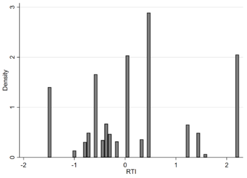

NOTE: figure/graphic rendered as an image from the PDF; its content is not machine-readable text. Caption (if any) follows as the next block.

**Figure A1.** Histogram routine-intensity index

**Table A1.** Effect of displacement on wages and employment

[output not shown]

NOTE: table converted from PDF layout to HTML text; cell boundaries are reconstructed. See PDF if exact alignment matters.

The table shows the baseline estimates of the estimates of time-to-event dummies interacted with a displacement indicator from a regression including individual, region, sector, time-to-event dummies, and year fixed effects. The dependent variables are relative wages and employment. Relative wages is measured dividing worker’s monthly average wage by the worker’s average wage in year *t* −2. Employment is a dummy equal to 1 if the worker has any positive labor earnings in a given year. Year *t* −2 is the base year. Heteroscedasticity robust standard errors clustered at individual level are reported in parenthesis. ***, **, and *, respectively, indicate 0.01, 0.05, and 0.1 levels of significance.

**Table A2.** Effect of displacement on relative wages and employment by occupational group

[output not shown]

NOTE: table converted from PDF layout to HTML text; cell boundaries are reconstructed. See PDF if exact alignment matters.

The table shows the baseline estimates of the estimates of time-to-event dummies interacted with a displacement indicator from a regression including individual, region, sector, time-to-event dummies, and year fixed effects. The dependent variables are relative wages and employment. Relative wages is measured by dividing workers’ monthly average wage by the average wage in year *t* −2. Employment is a dummy equal to 1 if the worker has any positive labor earnings in a given year. Low routines are workers in the first quartile of the routine-intensity index, while high routine indicates workers in the fourth quartile. Standard errors clustered at the individual level are reported in parentheses. ***, **, and *, respectively, indicate 0.01, 0.05, and 0.1 levels of significance.

**Table A3.** Comparison of workers in establishment’s closure and mass layoff

[output not shown]

NOTE: table converted from PDF layout to HTML text; cell boundaries are reconstructed. See PDF if exact alignment matters.

Table shows averages for baseline. The last column is the coefficient of a simple regression of treatment status on the variable, with robust standard errors. Stars indicate whether this difference is significant. **P* < 0.10, ***P* < 0.05, ****P* < 0.01.

**Table A4.** Comparison of switchers and non-switchers

[output not shown]

NOTE: table converted from PDF layout to HTML text; cell boundaries are reconstructed. See PDF if exact alignment matters.

Table shows averages for baseline. The last column is the coefficient of a simple regression of treatment status on the variable, with robust standard errors. Stars indicate whether this difference is significant. **P* < 0.10, ***P* < 0.05, ****P* < 0.01.

**Table A5.** Effect of displacement on wages and employment

[output not shown]

NOTE: table converted from PDF layout to HTML text; cell boundaries are reconstructed. See PDF if exact alignment matters.

(continued)

**Table A5.** (Continued)

|  |  | Dependentvariable |  |
| --- | --- | --- | --- |
|  | (1) Relativewage |  | (2) Relativeemployment |
| Individual Year Region Sector Observations | Yes Yes Yes Yes 2364444 , , |  | Yes Yes Yes Yes 2364444 , , |

NOTE: table converted from PDF layout to HTML text; cell boundaries are reconstructed. See PDF if exact alignment matters.

The table shows the baseline estimates of averages of the triple interactions between time-to-event dummies interacted with a displacement indicator and a RTI measure from a regression including individual, region, sector, time-to-event dummies, time-to-event dummies interacted with the RTI measure, and year fixed effects. The dependent variables are relative wages and employment. Relative wages is measured dividing worker’s monthly average wage by the worker’s average wage in year *t* −2. Employment is a dummy equal to 1 if the worker has any positive labor earnings in a given year. Year *t* −2 is the base year. Heteroscedasticity robust standard errors clustered at the individual are reported in parenthesis. ***, **, and *, respectively, indicate 0.01, 0.05, and 0.1 levels of significance.

**Table A6.** Change in RTI index by sector, 2006–2018

[output not shown]

NOTE: table converted from PDF layout to HTML text; cell boundaries are reconstructed. See PDF if exact alignment matters.

(continued)

**Table A6.** (Continued)

[output not shown]

NOTE: table converted from PDF layout to HTML text; cell boundaries are reconstructed. See PDF if exact alignment matters.